# COVID-19 US Southwest Forecasting

Jacob Bell, Jonathan Hake, Sean Lovullo

## Wrangling

Imports data, preps it, and shows a snippet of what it looks like

```r
train_data <- read_csv("train.csv",
    col_types = cols(
      Date = col_date(format = "%Y-%m-%d")
    )
  ) %>%
  mutate(Date = format(Date, "%Y/%m/%d")) %>%
  mutate(t = yday(Date) - 22) %>%
  select(Id, Province_State, Country_Region, t, Date, ConfirmedCases, Fatalities) %>%
  rename(Train_ID = Id) %>%
  mutate( isTrain = TRUE) #added the isTrain variable to show which data is training is which is not

head(train_data, 10)
```

| Train_ID | Province_State | Country_Region | t | Date | ConfirmedCases | Fatalities | isTrain |
| --- | --- | --- | --- | --- | --- | --- | --- |
| 1 | NA | Afghanistan | 0 | 2020/01/22 | 0 | 0 | TRUE |
| 2 | NA | Afghanistan | 1 | 2020/01/23 | 0 | 0 | TRUE |
| 3 | NA | Afghanistan | 2 | 2020/01/24 | 0 | 0 | TRUE |
| 4 | NA | Afghanistan | 3 | 2020/01/25 | 0 | 0 | TRUE |
| 5 | NA | Afghanistan | 4 | 2020/01/26 | 0 | 0 | TRUE |
| 6 | NA | Afghanistan | 5 | 2020/01/27 | 0 | 0 | TRUE |
| 7 | NA | Afghanistan | 6 | 2020/01/28 | 0 | 0 | TRUE |
| 8 | NA | Afghanistan | 7 | 2020/01/29 | 0 | 0 | TRUE |
| 9 | NA | Afghanistan | 8 | 2020/01/30 | 0 | 0 | TRUE |
| 10 | NA | Afghanistan | 9 | 2020/01/31 | 0 | 0 | TRUE |

Makes dataframe composed of only the US southwestern states (CA, NV, AZ, UT, NM, CO)

```r
sw_data <- train_data %>%
  filter(
    Province_State == "California" |
    Province_State == "Nevada" |
    Province_State == "Arizona" |
    Province_State == "Utah" |
    Province_State == "New Mexico" |
    Province_State == "Colorado"
  ) %>%
  arrange(Province_State, Date) %>%
  select(-Country_Region)

head(sw_data)
```

| Train_ID | Province_State | t | Date | ConfirmedCases | Fatalities | isTrain |
| --- | --- | --- | --- | --- | --- | --- |
| 27247 | Arizona | 0 | 2020/01/22 | 0 | 0 | TRUE |
| 27248 | Arizona | 1 | 2020/01/23 | 0 | 0 | TRUE |
| 27249 | Arizona | 2 | 2020/01/24 | 0 | 0 | TRUE |
| 27250 | Arizona | 3 | 2020/01/25 | 0 | 0 | TRUE |
| 27251 | Arizona | 4 | 2020/01/26 | 0 | 0 | TRUE |
| 27252 | Arizona | 5 | 2020/01/27 | 0 | 0 | TRUE |

Now we will import the test data. We also set up “t”, as days since 1/22/2020.

```r
test_data <- read_csv("test.csv",
        col_types = cols(
          Date = col_date(format = "%Y-%m-%d"))
)

#the test data does not have ConfirmedCases and Fatalities, so we must add those
test_data <- test_data %>%
  mutate( Date = format(Date, "%Y/%m/%d")) %>%
  rename( Test_ID = ForecastId) %>%         #renaming to match the same style as Train_ID
  mutate( t = yday( Date)-22 ) %>%
  mutate( ConfirmedCases = NA, Fatalities = NA, isTrain = FALSE ) #adding these columns with NA since it will be values that we will be predicting


#since there is an overlap of some dates in testing and training data, we will filter out some of the dates
test_data <- test_data %>%
  filter( t > 91)

head(test_data)
```

| Test_ID | Province_State | Country_Region | Date | t | ConfirmedCases | Fatalities | isTrain |
| --- | --- | --- | --- | --- | --- | --- | --- |
| 22 | NA | Afghanistan | 2020/04/23 | 92 | NA | NA | FALSE |
| 23 | NA | Afghanistan | 2020/04/24 | 93 | NA | NA | FALSE |
| 24 | NA | Afghanistan | 2020/04/25 | 94 | NA | NA | FALSE |
| 25 | NA | Afghanistan | 2020/04/26 | 95 | NA | NA | FALSE |
| 26 | NA | Afghanistan | 2020/04/27 | 96 | NA | NA | FALSE |
| 27 | NA | Afghanistan | 2020/04/28 | 97 | NA | NA | FALSE |

Make the test data only be on the southwest states with only the variables that we need.

```r
sw_test_data <- test_data %>%
  select( Test_ID, Province_State, t, Date, ConfirmedCases, Fatalities, isTrain) %>%
  filter( Province_State == 'California' |
            Province_State == 'Nevada' |
            Province_State == 'Utah' |
            Province_State == 'Arizona' |
            Province_State == 'Colorado' |
            Province_State == 'New Mexico'
          )

head(sw_test_data)
```

| Test_ID | Province_State | t | Date | ConfirmedCases | Fatalities | isTrain |
| --- | --- | --- | --- | --- | --- | --- |
| 10299 | Arizona | 92 | 2020/04/23 | NA | NA | FALSE |
| 10300 | Arizona | 93 | 2020/04/24 | NA | NA | FALSE |
| 10301 | Arizona | 94 | 2020/04/25 | NA | NA | FALSE |
| 10302 | Arizona | 95 | 2020/04/26 | NA | NA | FALSE |
| 10303 | Arizona | 96 | 2020/04/27 | NA | NA | FALSE |
| 10304 | Arizona | 97 | 2020/04/28 | NA | NA | FALSE |

In order to merge these 2 datasets, they need to have the same # of columns. Now, with rbind(), we will tack “sw_test_data” on to the end of our original “sw_data” so we will have all possible dates.

```r
#take out train_Id and test_Id in both datasets to have the same columns
sw_data <- sw_data %>%
  select(Province_State, t, Date, ConfirmedCases, Fatalities, isTrain)

sw_test_data <- sw_test_data %>%
  select( Province_State, t, Date, ConfirmedCases, Fatalities, isTrain)

sw_data_combined <- rbind( sw_data, sw_test_data)

head(sw_data_combined)
```

| Province_State | t | Date | ConfirmedCases | Fatalities | isTrain |
| --- | --- | --- | --- | --- | --- |
| Arizona | 0 | 2020/01/22 | 0 | 0 | TRUE |
| Arizona | 1 | 2020/01/23 | 0 | 0 | TRUE |
| Arizona | 2 | 2020/01/24 | 0 | 0 | TRUE |
| Arizona | 3 | 2020/01/25 | 0 | 0 | TRUE |
| Arizona | 4 | 2020/01/26 | 0 | 0 | TRUE |
| Arizona | 5 | 2020/01/27 | 0 | 0 | TRUE |

## Modeling

First step is to add the extra data needed for the model. A CSV file has already been wrangled to a certain degree, but now it needs to be joined to our main data set. After that, columns for ln(ConfirmedCases) and ln(Fatalities) are computed in order to build a linear model.

```r
extra_data <- read_csv(
    "final_combined.csv",
    col_types = cols(
        DATE = col_date(format = "%m/%d/%Y")
    )
  ) %>%
  mutate(DATE = format(DATE, "%Y/%m/%d")) %>%
  mutate(t = yday(DATE) - 22) %>%
  select(STATE, STATION, DATE, t, everything())

sw_data_combined <- left_join(sw_data_combined, extra_data, by = c("Province_State" = "STATE", "t"))

sw_data_combined <- sw_data_combined %>%
  select(-DATE) %>%
  select(Province_State, Date, t, isTrain, ConfirmedCases, Fatalities, everything()) %>%
  arrange(Province_State, Date)

ln_sw_data <- sw_data_combined %>%
  mutate(
    `ln(ConfirmedCases)` = log(ConfirmedCases),
    `ln(Fatalities)` = log(Fatalities)
  ) %>%
  mutate(
    `ln(ConfirmedCases)` = replace(`ln(ConfirmedCases)`, `ln(ConfirmedCases)` == -Inf, NA),
    `ln(Fatalities)` = replace(`ln(Fatalities)`, `ln(Fatalities)` == -Inf, NA)
  ) %>%
  select(Province_State, Date, t, isTrain, ConfirmedCases, Fatalities, `ln(ConfirmedCases)`, `ln(Fatalities)`, everything())

ln_sw_data
```

| Province_State | Date | t | isTrain | ConfirmedCases | Fatalities | ln(ConfirmedCases) | ln(Fatalities) | STATION | REPORT_TYPE | STATION.LATITUDE | STATION.LONGITUDE | DailyAverageDryBulbTemperature | DailyMaximumDryBulbTemperature | DailyMinimumDryBulbTemperature | POPULATION | STATE_AREA | STATE_DENSITY | MEDIAN_AGE | MEDIAN_HOUSEHOLD_INCOME | POVERTY_RATE | EMPLOYMENT_RATE |
| --- | --- | --- | --- | --- | --- | --- | --- | --- | --- | --- | --- | --- | --- | --- | --- | --- | --- | --- | --- | --- | --- |
| Arizona | 2020/01/22 | 0 | TRUE | 0 | 0 | NA | NA | PHOENIX | SOD | 33.43 | -112.00 | 58.0 | 64.0 | 51.0 | 7171646 | 113563.6 | 63.151 | 38.0 | 59246 | 14.0 | 56.3 |
| Arizona | 2020/01/23 | 1 | TRUE | 0 | 0 | NA | NA | PHOENIX | SOD | 33.43 | -112.00 | 59.0 | 71.0 | 47.0 | 7171646 | 113564.6 | 63.150 | 38.0 | 59246 | 14.0 | 56.3 |
| Arizona | 2020/01/24 | 2 | TRUE | 0 | 0 | NA | NA | PHOENIX | SOD | 33.43 | -112.00 | 61.0 | 73.0 | 48.0 | 7171646 | 113565.6 | 63.150 | 38.0 | 59246 | 14.0 | 56.3 |
| Arizona | 2020/01/25 | 3 | TRUE | 0 | 0 | NA | NA | PHOENIX | SOD | 33.43 | -112.00 | 61.0 | 73.0 | 48.0 | 7171646 | 113566.6 | 63.149 | 38.0 | 59246 | 14.0 | 56.3 |
| Arizona | 2020/01/26 | 4 | TRUE | 0 | 0 | NA | NA | PHOENIX | SOD | 33.43 | -112.00 | 61.0 | 73.0 | 49.0 | 7171646 | 113567.6 | 63.149 | 38.0 | 59246 | 14.0 | 56.3 |
| Arizona | 2020/01/27 | 5 | TRUE | 0 | 0 | NA | NA | PHOENIX | SOD | 33.43 | -112.00 | 63.0 | 74.0 | 51.0 | 7171646 | 113568.6 | 63.148 | 38.0 | 59246 | 14.0 | 56.3 |
| Arizona | 2020/01/28 | 6 | TRUE | 0 | 0 | NA | NA | PHOENIX | SOD | 33.43 | -112.00 | 59.0 | 72.0 | 46.0 | 7171646 | 113569.6 | 63.148 | 38.0 | 59246 | 14.0 | 56.3 |
| Arizona | 2020/01/29 | 7 | TRUE | 0 | 0 | NA | NA | PHOENIX | SOD | 33.43 | -112.00 | 57.0 | 67.0 | 47.0 | 7171646 | 113570.6 | 63.147 | 38.0 | 59246 | 14.0 | 56.3 |
| Arizona | 2020/01/30 | 8 | TRUE | 0 | 0 | NA | NA | PHOENIX | SOD | 33.43 | -112.00 | 58.0 | 70.0 | 45.0 | 7171646 | 113571.6 | 63.146 | 38.0 | 59246 | 14.0 | 56.3 |
| Arizona | 2020/01/31 | 9 | TRUE | 0 | 0 | NA | NA | PHOENIX | SOD | 33.43 | -112.00 | 59.0 | 73.0 | 44.0 | 7171646 | 113572.6 | 63.146 | 38.0 | 59246 | 14.0 | 56.3 |

[output cut: 674 more lines]

Makes individual dataframes for each state. (I changed sw_data to sw_data_combined to reflect that it has training and testing dates in it)

```r
az_data <- sw_data_combined %>%
  filter(Province_State == "Arizona") %>%
  arrange(Date)

ca_data <- sw_data_combined %>%
  filter(Province_State == "California") %>%
  arrange(Date)

co_data <- sw_data_combined %>%
  filter(Province_State == "Colorado") %>%
  arrange(Date)

nv_data <- sw_data_combined %>%
  filter(Province_State == "Nevada") %>%
  arrange(Date)

nm_data <- sw_data_combined %>%
  filter(Province_State == "New Mexico") %>%
  arrange(Date)

ut_data <- sw_data_combined %>%
  filter(Province_State == "Utah") %>%
  arrange(Date)

ut_data #to show how train & test go together in the data
```

[output not shown]

[output cut: 104 more lines]

## Graphics

Plots area graphs of confirmed cases and fatalites for each state based on the pure given data

### Arizona

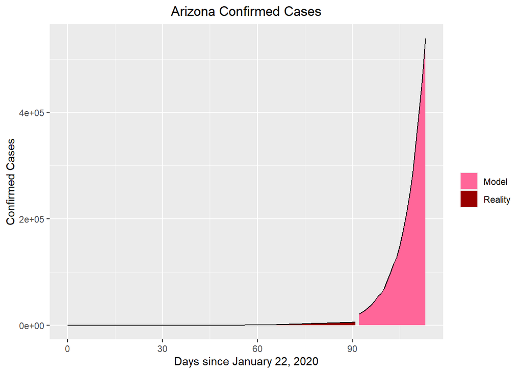

```r
ggplot(az_data, mapping = aes(x = t, y = ConfirmedCases, group = isTrain)) +
  geom_area(aes(fill = isTrain)) +
  geom_line() +
  scale_fill_manual(
    labels = c('Model','Reality'),
    values=c('#FF6699','#990000')
  )+
  ggtitle("Arizona Confirmed Cases") +
  theme(plot.title = element_text(hjust = 0.5)) +
  xlab("Days since January 22, 2020") +
  ylab("Confirmed Cases") +
  labs(fill = "")
```

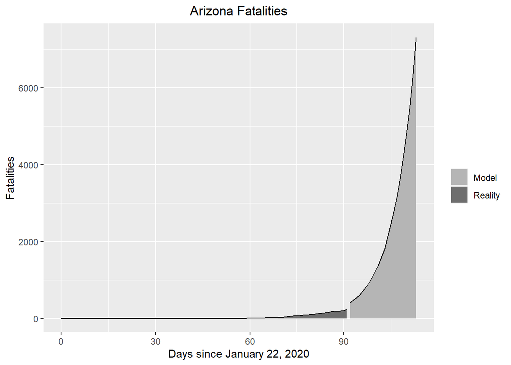

```r
ggplot(az_data, mapping = aes(x = t, y = Fatalities, group = isTrain)) +
  geom_area(aes(fill = isTrain)) +
  geom_line() +
  scale_fill_manual(
    labels = c('Model','Reality'),
    values=c('#B5B5B5','#6E6E6E')
  )+
  ggtitle("Arizona Fatalities") +
  theme(plot.title = element_text(hjust = 0.5)) +
  xlab("Days since January 22, 2020") +
  ylab("Fatalities") +
  labs(fill = "")
```

### California

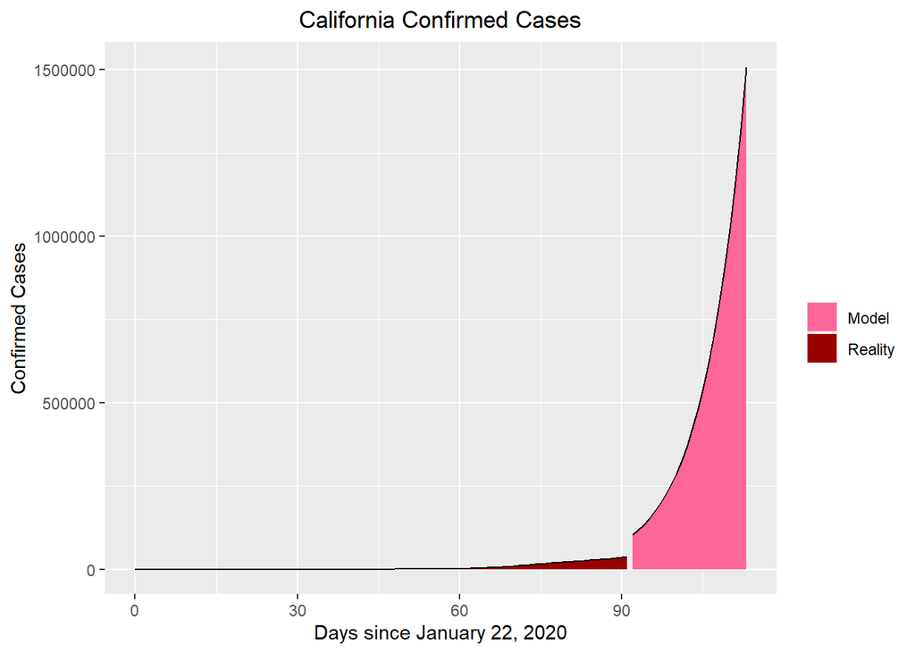

```r
ggplot(ca_data, mapping = aes(x = t, y = ConfirmedCases, group = isTrain)) +
  geom_area(aes(fill = isTrain)) +
  geom_line() +
  scale_fill_manual(
    labels = c('Model','Reality'),
    values=c('#FF6699','#990000')
  )+
  ggtitle("California Confirmed Cases") +
  theme(plot.title = element_text(hjust = 0.5)) +
  xlab("Days since January 22, 2020") +
  ylab("Confirmed Cases") +
  labs(fill = "")
```

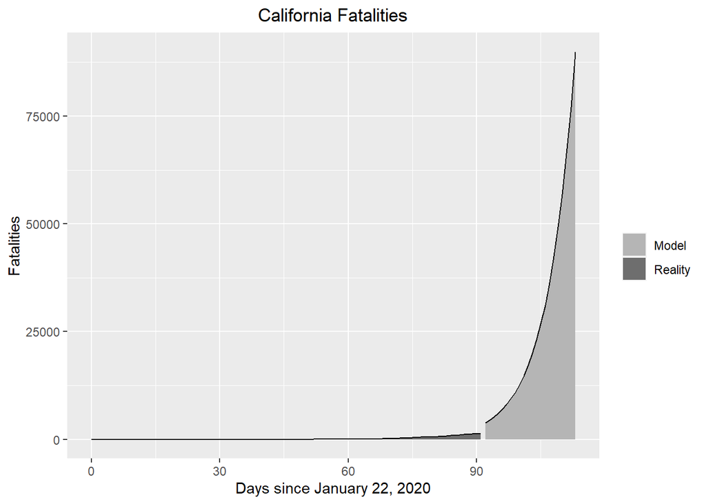

```r
ggplot(ca_data, mapping = aes(x = t, y = Fatalities, group = isTrain)) +
  geom_area(aes(fill = isTrain)) +
  geom_line() +
  scale_fill_manual(
    labels = c('Model','Reality'),
    values=c('#B5B5B5','#6E6E6E')
  )+
  ggtitle("California Fatalities") +
  theme(plot.title = element_text(hjust = 0.5)) +
  xlab("Days since January 22, 2020") +
  ylab("Fatalities") +
  labs(fill = "")
```

### Colorado

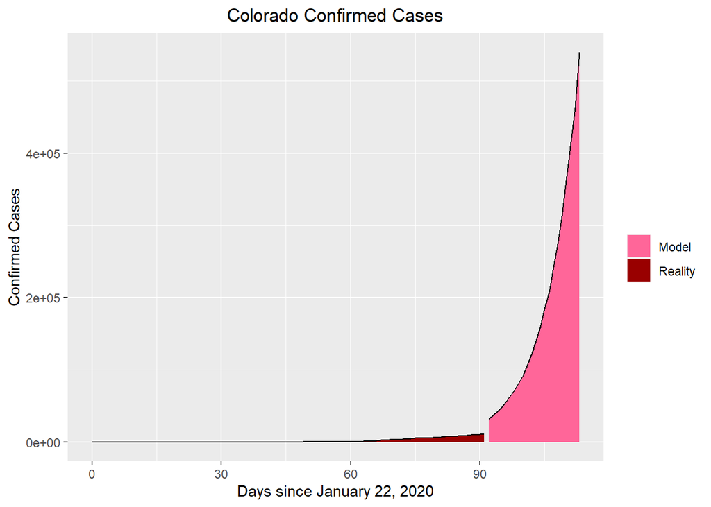

```r
ggplot(co_data, mapping = aes(x = t, y = ConfirmedCases, group = isTrain)) +
  geom_area(aes(fill = isTrain)) +
  geom_line() +
  scale_fill_manual(
    labels = c('Model','Reality'),
    values=c('#FF6699','#990000')
  )+
  ggtitle("Colorado Confirmed Cases") +
  theme(plot.title = element_text(hjust = 0.5)) +
  xlab("Days since January 22, 2020") +
  ylab("Confirmed Cases") +
  labs(fill = "")
```

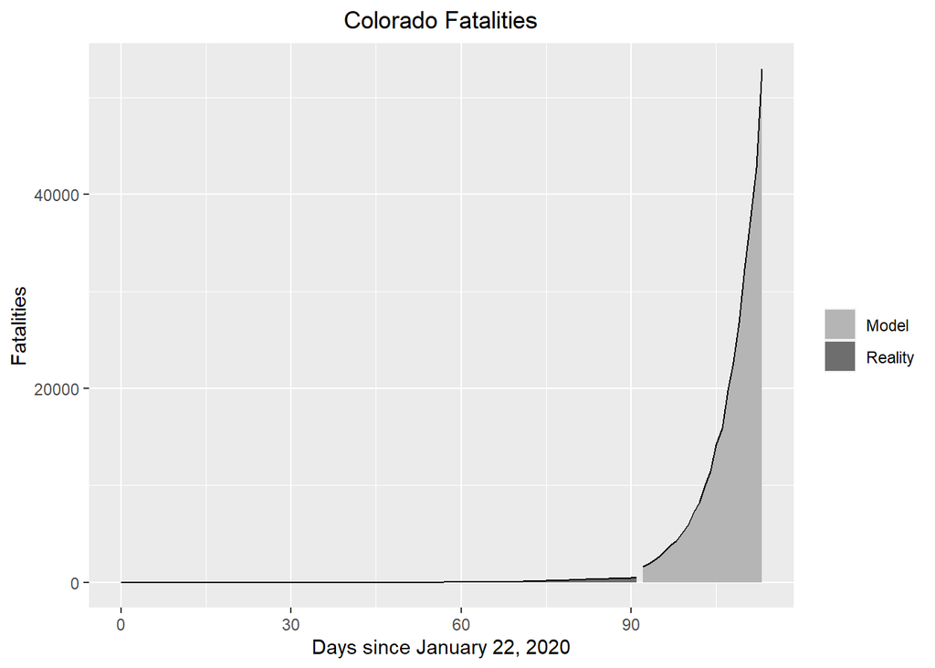

```r
ggplot(co_data, mapping = aes(x = t, y = Fatalities, group = isTrain)) +
  geom_area(aes(fill = isTrain)) +
  geom_line() +
  scale_fill_manual(
    labels = c('Model','Reality'),
    values=c('#B5B5B5','#6E6E6E')
  )+
  ggtitle("Colorado Fatalities") +
  theme(plot.title = element_text(hjust = 0.5)) +
  xlab("Days since January 22, 2020") +
  ylab("Fatalities") +
  labs(fill = "")
```

### Nevada

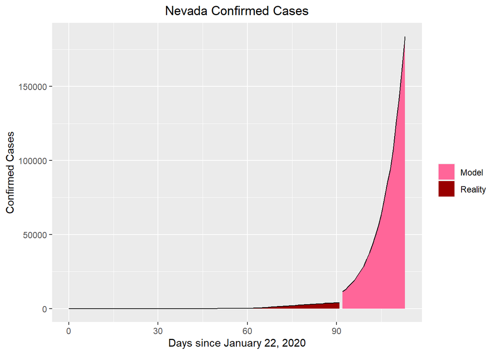

```r
ggplot(nv_data, mapping = aes(x = t, y = ConfirmedCases, group = isTrain)) +
  geom_area(aes(fill = isTrain)) +
  geom_line() +
  scale_fill_manual(
    labels = c('Model','Reality'),
    values=c('#FF6699','#990000')
  )+
  ggtitle("Nevada Confirmed Cases") +
  theme(plot.title = element_text(hjust = 0.5)) +
  xlab("Days since January 22, 2020") +
  ylab("Confirmed Cases") +
  labs(fill = "")
```

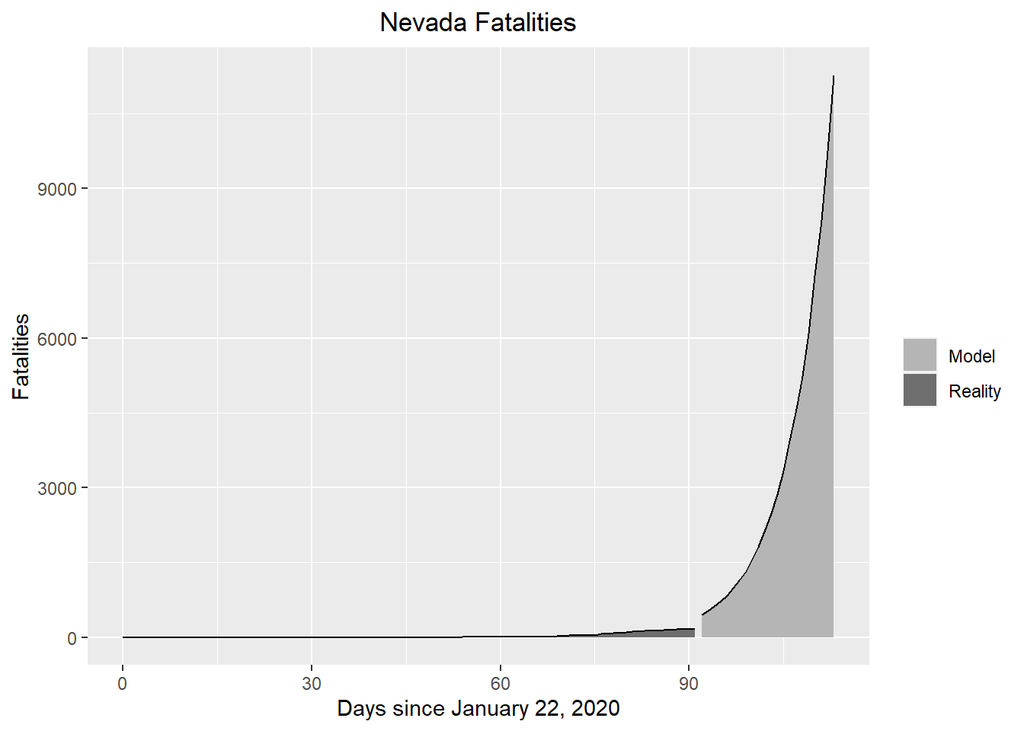

```r
ggplot(nv_data, mapping = aes(x = t, y = Fatalities, group = isTrain)) +
  geom_area(aes(fill = isTrain)) +
  geom_line() +
  scale_fill_manual(
    labels = c('Model','Reality'),
    values=c('#B5B5B5','#6E6E6E')
  )+
  ggtitle("Nevada Fatalities") +
  theme(plot.title = element_text(hjust = 0.5)) +
  xlab("Days since January 22, 2020") +
  ylab("Fatalities") +
  labs(fill = "")
```

### New Mexico

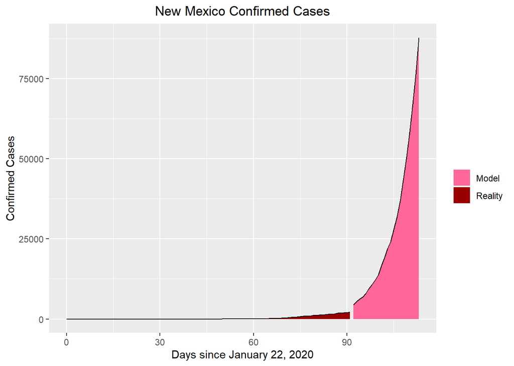

```r
ggplot(nm_data, mapping = aes(x = t, y = ConfirmedCases, group = isTrain)) +
  geom_area(aes(fill = isTrain)) +
  geom_line() +
  scale_fill_manual(
    labels = c('Model','Reality'),
    values=c('#FF6699','#990000')
  )+
  ggtitle("New Mexico Confirmed Cases") +
  theme(plot.title = element_text(hjust = 0.5)) +
  xlab("Days since January 22, 2020") +
  ylab("Confirmed Cases") +
  labs(fill = "")
```

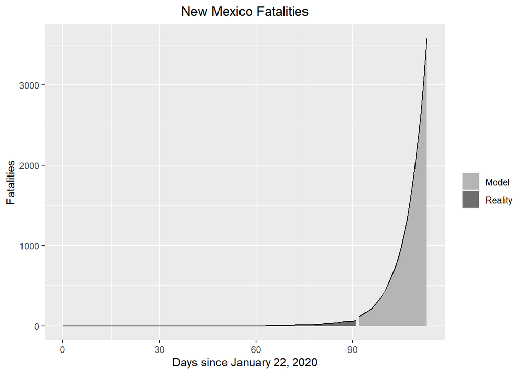

```r
ggplot(nm_data, mapping = aes(x = t, y = Fatalities, group = isTrain)) +
  geom_area(aes(fill = isTrain)) +
  geom_line() +
  scale_fill_manual(
    labels = c('Model','Reality'),
    values=c('#B5B5B5','#6E6E6E')
  )+
  ggtitle("New Mexico Fatalities") +
  theme(plot.title = element_text(hjust = 0.5)) +
  xlab("Days since January 22, 2020") +
  ylab("Fatalities") +
  labs(fill = "")
```

### Utah

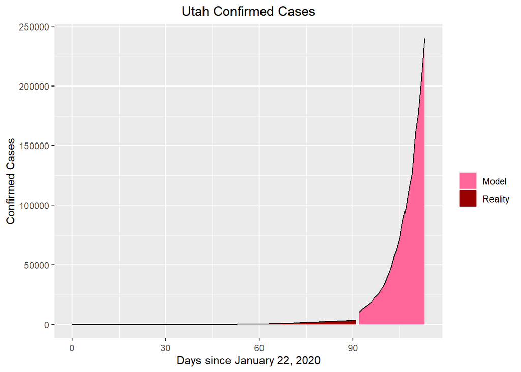

```r
ggplot(ut_data, mapping = aes(x = t, y = ConfirmedCases, group = isTrain)) +
  geom_area(aes(fill = isTrain)) +
  geom_line() +
  scale_fill_manual(
    labels = c('Model','Reality'),
    values=c('#FF6699','#990000')
  )+
  ggtitle("Utah Confirmed Cases") +
  theme(plot.title = element_text(hjust = 0.5)) +
  xlab("Days since January 22, 2020") +
  ylab("Confirmed Cases") +
  labs(fill = "")
```

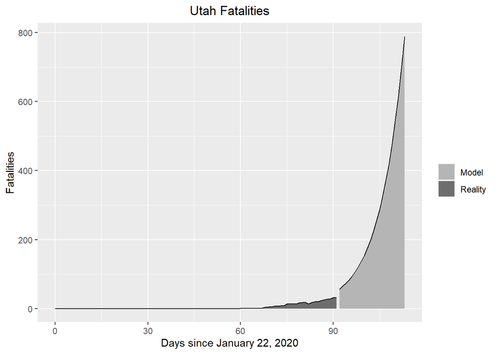

```r
ggplot(ut_data, mapping = aes(x = t, y = Fatalities, group = isTrain)) +
  geom_area(aes(fill = isTrain)) +
  geom_line() +
  scale_fill_manual(
    labels = c('Model','Reality'),
    values=c('#B5B5B5','#6E6E6E')
  )+
  ggtitle("Utah Fatalities") +
  theme(plot.title = element_text(hjust = 0.5)) +
  xlab("Days since January 22, 2020") +
  ylab("Fatalities") +
  labs(fill = "")
```

Comparison with Southwestern States

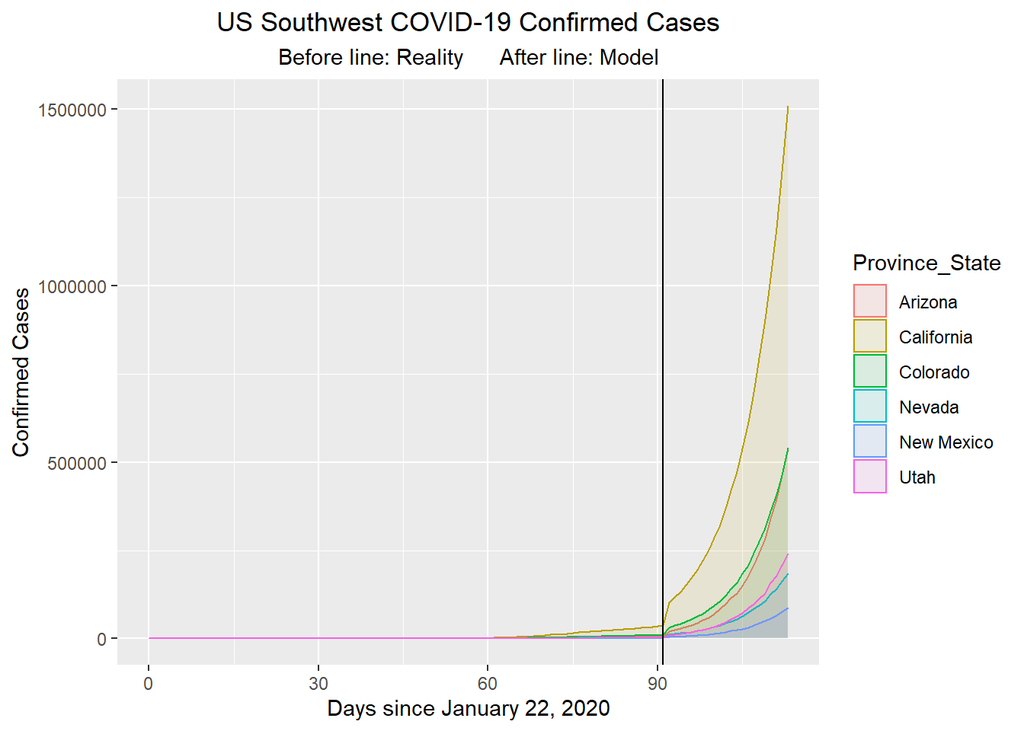

```r
ggplot(sw_data_combined,
       mapping = aes(
         x = t,
         y = ConfirmedCases,
         color = Province_State,
         fill = Province_State
      )
  ) +
  geom_area(position = 'identity', alpha = 0.1) +
  geom_vline(xintercept = 91, color = "black")+
  ggtitle(
    label = "US Southwest COVID-19 Confirmed Cases",
    subtitle = "Before line: Reality      After line: Model"
  ) +
  theme(
    plot.title = element_text(hjust = 0.5),
    plot.subtitle = element_text(hjust = 0.5)
  ) +
  xlab("Days since January 22, 2020") +
  ylab("Confirmed Cases")
```

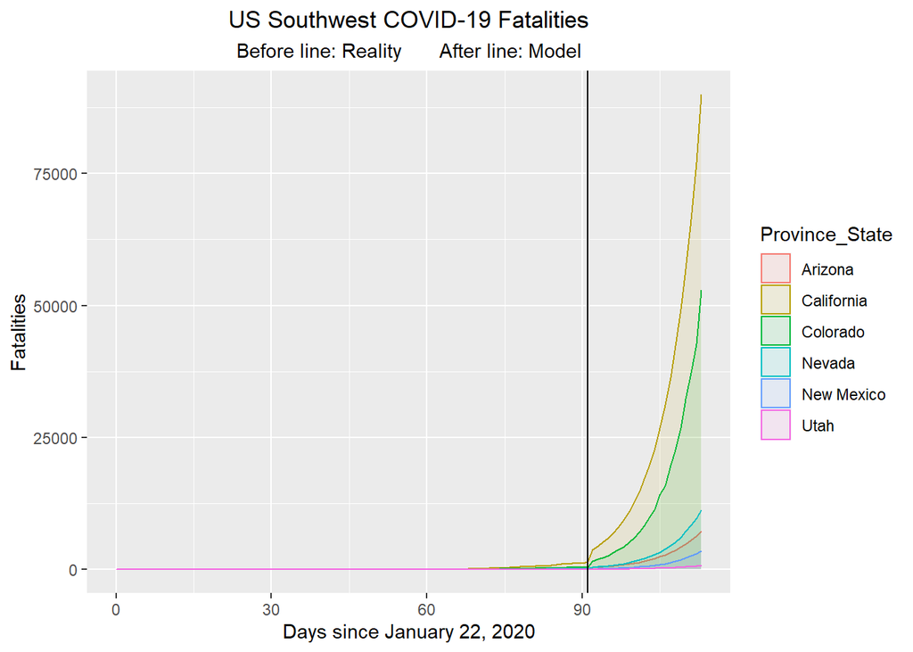

```r
ggplot(sw_data_combined,
       mapping = aes(
         x = t,
         y = Fatalities,
         color = Province_State,
         fill = Province_State
      )
  ) +
  geom_area(position = 'identity', alpha = 0.1) +
  geom_vline(xintercept = 91, color = "black")+
  ggtitle(
    label = "US Southwest COVID-19 Fatalities",
    subtitle = "Before line: Reality       After line: Model"
  ) +
  theme(
    plot.title = element_text(hjust = 0.5),
    plot.subtitle = element_text(hjust = 0.5)
  ) +
  xlab("Days since January 22, 2020") +
  ylab("Fatalities")
```

Creates plot of ln(ConfirmedCases) and ln(Fatalities) to show the predictions from the linear models

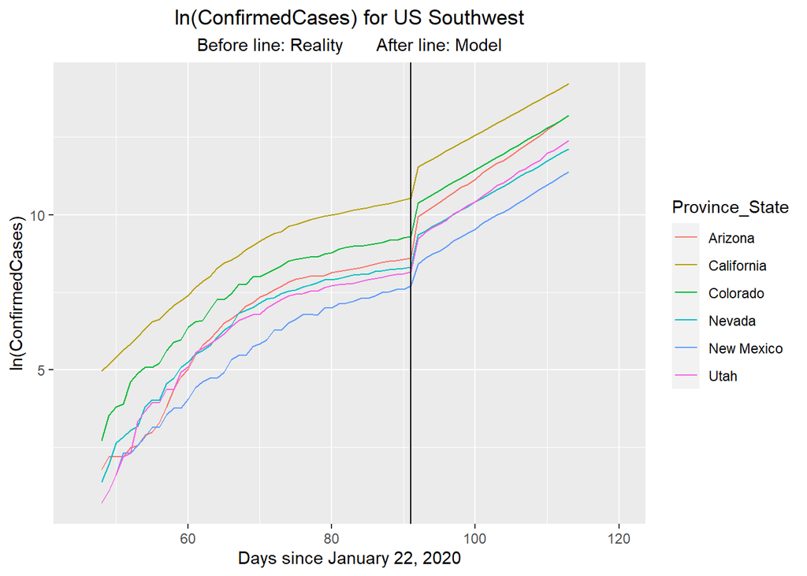

```r
ln_reality <- ln_sw_data %>%
  filter(
    !is.na(ConfirmedCases) &
      !is.na(Fatalities)
  )

ln_prediction <- modeled_ln_data %>%
  select(
    -`ln(ConfirmedCases)`,
    -`ln(Fatalities)`
  ) %>%
  rename(
    `ln(ConfirmedCases)` = ln_cc_pred,
    `ln(Fatalities)` = ln_f_pred
  )

ln_graph_data <- anti_join(ln_reality, ln_prediction, by = c("Province_State", "t")) %>%
  bind_rows(ln_prediction) %>%
  arrange(Province_State, t)

ggplot(
  ln_graph_data,
  aes(x = t, y = `ln(ConfirmedCases)`,
      color = Province_State)
) +
  geom_line() +
  geom_vline(xintercept = 91, color = "black")+
  xlim(45,120) +
  ggtitle("ln(ConfirmedCases) for US Southwest",
          subtitle = "Before line: Reality       After line: Model") +
  theme(plot.title = element_text(hjust = 0.5), plot.subtitle = element_text(hjust = 0.5)) +
  xlab("Days since January 22, 2020") +
  ylab("ln(ConfirmedCases)")
```

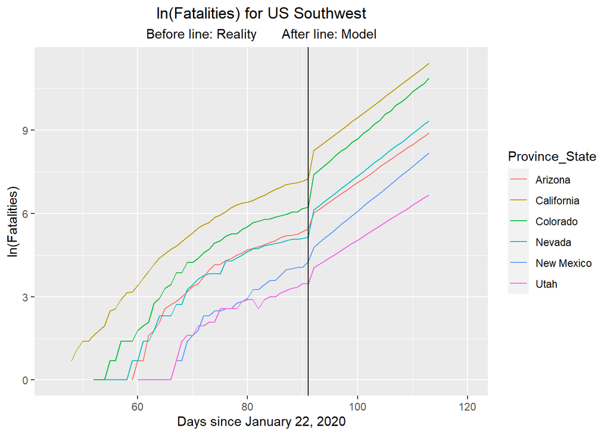

```r
ggplot(
  ln_graph_data,
  aes(x = t, y = `ln(Fatalities)`,
      color = Province_State)
) +
  geom_line() +
  geom_vline(xintercept = 91, color = "black")+
  xlim(45,120) +
  ggtitle("ln(Fatalities) for US Southwest",
          subtitle = "Before line: Reality       After line: Model") +
  theme(plot.title = element_text(hjust = 0.5), plot.subtitle = element_text(hjust = 0.5)) +
  xlab("Days since January 22, 2020") +
  ylab("ln(Fatalities)")
```

## Animations

Animation of US SW Confirmed Cases

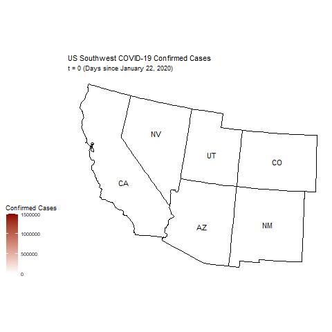

US Southwest COVID-19 Confirmed Cases Map Animation

```r
plot_usmap(
  data = sw_data_combined %>%
    rename(state = Province_State),
  values = "ConfirmedCases",
  include = c("CA", "NV", "AZ", "UT", "CO", "NM"),
  color = "Black",
  labels = TRUE
  ) +
  scale_fill_continuous(
    low = "White",
    high = "DarkRed",
    name = "Confirmed Cases"
  ) +
  theme(legend.position = "left") +
  labs(
    title = "US Southwest COVID-19 Confirmed Cases",
    subtitle = 't = {frame_time} (Days since January 22, 2020)'
  )+
  transition_time(as.integer(t)) +
  ease_aes('linear')
```

Animation of US SW Fatalities

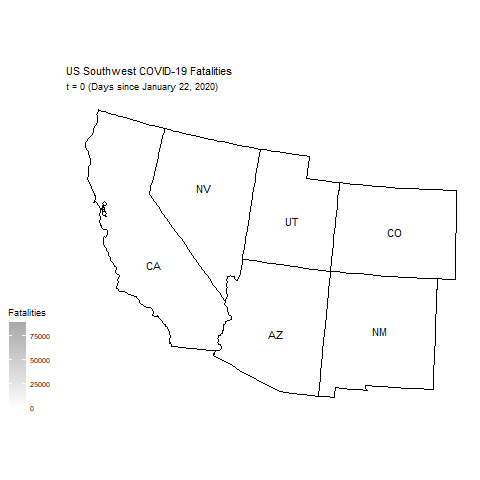

US Southwest COVID-19 Fatalities Map Animation

```r
plot_usmap(
  data = sw_data_combined %>%
    rename(state = Province_State),
  values = "Fatalities",
  include = c("CA", "NV", "AZ", "UT", "CO", "NM"),
  color = "Black",
  labels = TRUE
  ) +
  scale_fill_continuous(
    low = "White",
    high = "DarkGray",
    name = "Fatalities"
  ) +
  theme(legend.position = "left") +
  labs(
    title = "US Southwest COVID-19 Fatalities",
    subtitle = 't = {frame_time} (Days since January 22, 2020)'
  )+
  transition_time(as.integer(t)) +
  ease_aes('linear')
```